# Задачи по Эконометрике: F-тест

Н.В. Артамонов (МГИМО МИД России)

Для каждой задачи оцените соотвествующие регрессии и проведите F-тест в Python

# 1 F-тест: значимость регрессии

## 1.1 sleep equation #1

Для набора данных `sleep75` рассмотрим несколько регрессий

```
============================================================
                          Зависимая переменная
             -----------------------------------------------
                                  sleep
                 (1)         (2)         (3)         (4)
------------------------------------------------------------
totwrk        -0.167***   -0.168***   -0.167***
               (0.018)     (0.018)     (0.018)

age            -7.631      -6.581      -6.255
              (11.363)    (11.292)    (11.191)

I(age2)         0.124       0.112       0.109
               (0.135)     (0.134)     (0.134)

south         100.608**   98.163**   114.547***
              (41.969)    (41.825)    (40.637)

male          86.626**    92.256***   90.457***
              (35.181)    (34.571)    (34.257)

smsa           -53.905    -57.046*                -57.890*
              (33.199)    (32.979)                (34.293)

yngkid         -17.960     -13.366                 -31.138
              (50.747)    (50.178)                (50.424)

marr           34.984                              60.098
              (42.452)                            (44.167)

union          13.369                               7.327
              (38.225)                            (40.530)

Constant     3638.289*** 3650.673*** 3613.995*** 3242.521***
              (223.997)   (223.367)   (218.433)   (44.044)

------------------------------------------------------------
Observations     706         706         706         706
R2              0.132       0.131       0.128       0.007
Adjusted R2     0.121       0.123       0.121       0.002
============================================================
Note:                            *p<0.1; **p<0.05; ***p<0.01
```

Тестируется значимость каждой регрессии. Уровень значимости 5%. Вычислите соотвествующию тестовые статистики. **Ответ округлите до 2-х десятичных знаков.**

Ответ

```
================
Регрессия F.stat
----------------
1         11.76
2         15.03
3         20.55
4          1.24
----------------
```

Вычислите критическое значение для каждой регрессии. **Ответ округлите до 2-х десятичных знаков.**

Ответ

```
==============
Регрессия F.cr
--------------
1         1.89
2         2.02
3         2.23
4         2.38
--------------
```

Какая из регрессий значима?

```
====================
Регрессия Значимость
--------------------
1          Значима
2          Значима
3          Значима
4         Незначима
--------------------
```

## 1.2 cost equation #1

Для набора данных `Electricity` рассмотрим несколько регрессий

```
============================================================
                          Зависимая переменная
             -----------------------------------------------
                                log(cost)
                (1)       (2)       (3)       (4)      (5)
------------------------------------------------------------
log(q)       0.838***  0.836***  0.839***
              (0.009)   (0.013)   (0.009)

log(pl)        0.044                        1.748**  1.457**
              (0.106)                       (0.756)  (0.715)

log(pk)       0.188**             0.178**   1.247**
              (0.087)             (0.083)   (0.627)

log(pf)      0.713***            0.720***    0.194
              (0.064)             (0.062)   (0.466)

Constant     -7.472*** -3.841*** -7.061*** -18.572** -10.002
              (1.063)   (0.107)   (0.402)   (7.670)  (6.413)

------------------------------------------------------------
Observations    158       158       158       158      158
R2             0.982     0.965     0.982     0.053    0.026
Adjusted R2    0.982     0.965     0.982     0.035    0.020
============================================================
Note:                            *p<0.1; **p<0.05; ***p<0.01
```

Тестируется значимость каждой регрессии. Уровень значимости 1%. Вычислите соотвествующию тестовые статистики. **Ответ округлите до 2-х десятичных знаков.**

Ответ

```
=================
Регрессия F.stat
-----------------
1         2086.75
2         4301.14
3         2800.52
4          2.87
5          4.16
-----------------
```

Вычислите критическое значение для каждой регрессии. **Ответ округлите до 2-х десятичных знаков.**

Ответ

```
==============
Регрессия F.cr
--------------
1         3.44
2         6.80
3         3.91
4         3.91
5         6.80
--------------
```

Какая из регрессий значима?

```
====================
Регрессия Значимость
--------------------
1          Значима
2          Значима
3          Значима
4         Незначима
5         Незначима
--------------------
```

## 1.3 sleep equation #2

Для набора данных `sleep75` рассмотрим несколько регрессий

```
===================================================================
                                 Зависимая переменная
                    -----------------------------------------------
                                         sleep
                        (1)         (2)         (3)         (4)
-------------------------------------------------------------------
totwrk               -0.147***
                      (0.017)

age                   -8.800     -22.785*    -21.490*
                     (11.428)    (11.907)    (11.737)

I(age2)                0.142      0.317**     0.301**
                      (0.136)     (0.141)     (0.140)

smsa                 -69.437**   -57.707*                -57.890*
                     (32.422)    (34.088)                (34.293)

yngkid                 1.631      -3.184                  -31.138
                     (50.691)    (53.338)                (50.424)

marr                  47.551      62.147                  60.098
                     (42.008)    (44.169)                (44.167)

union                 13.492      16.228                   7.327
                     (38.369)    (40.374)                (40.530)

Constant            3673.756*** 3601.335*** 3608.030*** 3242.521***
                     (224.507)   (236.085)   (230.646)   (44.044)

-------------------------------------------------------------------
Observations            706         706         706         706
R2                     0.118       0.022       0.015       0.007
Adjusted R2            0.110       0.014       0.012       0.002
Residual Std. Error   419.371     441.301     441.775     444.018
F Statistic          13.387***    2.663**    5.224***      1.314
===================================================================
Note:                                   *p<0.1; **p<0.05; ***p<0.01
```

Тестируется значимость каждой регрессии. Уровень значимости 1%.

Какая из регрессий значима?

```
====================
Регрессия Значимость
--------------------
1          Значима
2         Незначима
3          Значима
4         Незначима
--------------------
```

## 1.4 cost equation #2

Для набора данных `Electricity` рассмотрим несколько регрессий

```
=========================================================================
                                    Зависимая переменная
                    -----------------------------------------------------
                                          log(cost)
                        (1)         (2)         (3)        (4)      (5)
-------------------------------------------------------------------------
log(q)               0.403***    0.390***    0.838***
                      (0.032)     (0.054)     (0.009)

I(log(q)2)           0.030***    0.031***
                      (0.002)     (0.004)

log(pl)               0.146**                  0.044     1.748**  1.457**
                      (0.070)                 (0.106)    (0.756)  (0.715)

log(pk)              0.157***                 0.188**    1.247**
                      (0.058)                 (0.087)    (0.627)

log(pf)              0.685***                0.713***     0.194
                      (0.043)                 (0.064)    (0.466)

Constant             -6.739***   -2.394***   -7.472***  -18.572** -10.002
                      (0.706)     (0.194)     (1.063)    (7.670)  (6.413)

-------------------------------------------------------------------------
Observations            158         158         158        158      158
R2                     0.992       0.976       0.982      0.053    0.026
Adjusted R2            0.992       0.976       0.982      0.035    0.020
Residual Std. Error    0.138       0.239       0.209      1.516    1.527
F Statistic         3880.407*** 3185.767*** 2106.934***  2.881**  4.158**
=========================================================================
Note:                                         *p<0.1; **p<0.05; ***p<0.01
```

Тестируется значимость каждой регрессии. Уровень значимости 1%.

Какая из регрессий значима?

```
====================
Регрессия Значимость
--------------------
1          Значима
2          Значима
3          Значима
4         Незначима
5         Незначима
--------------------
```

# 2 F-тест: совместная значимость

## 2.1 sleep equation #1

Для датасета `sleep75` рассмотрим регрессию **sleep на totwrk, age, male, south, smsa, yngkid, marr, union**

Результаты подгонки (коэффициенты)

```
t test of coefficients:

               Estimate  Std. Error t value Pr(>|t|)
(Intercept) 3446.830301   81.839915 42.1167  < 2e-16 ***
totwrk        -0.169130    0.018074 -9.3577  < 2e-16 ***
age            2.714483    1.472374  1.8436  0.06566 .
male          87.108150   35.173210  2.4765  0.01350 *
south        102.271833   41.925047  2.4394  0.01496 *
smsa         -54.187710   33.193402 -1.6325  0.10303
yngkid       -13.051272   50.459104 -0.2587  0.79598
marr          31.360412   42.263190  0.7420  0.45832
union         11.865664   38.185877  0.3107  0.75610
---
Signif. codes:  0 '***' 0.001 '**' 0.01 '*' 0.05 '.' 0.1 ' ' 1
```

Уровень значимости 5%. Какие коэффициенты значимы? Ответ

```
[1] "totwrk" "male"   "south"
```

Потестируем совместную значимость `smsa, yngkid, marr, union`, т.е. гипотезу $H_0:\beta_{smsa}=\beta_{yngkid}=\beta_{marr}=\beta_{union}=0$

Регрессия с ограниченияим: **sleep на totwrk, age, male, south**

Исходная регрессия и регрессия с ограничениями в одной таблице

```
================================================
                        Зависимая переменная
                    ----------------------------
                               sleep
                         (1)            (2)
------------------------------------------------
totwrk                -0.169***      -0.169***
                       (0.018)        (0.018)

age                     2.714*        2.785**
                       (1.472)        (1.387)

male                   87.108**      90.743***
                       (35.173)      (34.247)

south                 102.272**     116.443***
                       (41.925)      (40.561)

smsa                   -54.188
                       (33.193)

yngkid                 -13.051
                       (50.459)

marr                    31.360
                       (42.263)

union                   11.866
                       (38.186)

Constant             3446.830***    3444.997***
                       (81.840)      (67.882)

------------------------------------------------
Observations             706            706
R2                      0.131          0.127
Adjusted R2             0.121          0.122
Residual Std. Error    416.565        416.458
F Statistic           13.176***      25.456***
================================================
Note:                *p<0.1; **p<0.05; ***p<0.01
```

Вычислите тестовую статистику. **Ответ округлите до 3-х десятичных знаков.**

Ответ:

```
[1] 0.802
```

Вычислите критическое значение. **Ответ округлите до 3-х десятичных знаков.**

```
[1] 2.385
```

Значимо ли совместное влияние? Ответ

```
[1] "Незначимо"
```

## 2.2 sleep equation #2

Для датасета `sleep75` рассмотрим регрессию **sleep на totwrk, age, age^2, male, south**

Результаты подгонки (коэффициенты)

```
t test of coefficients:

               Estimate  Std. Error t value  Pr(>|t|)
(Intercept) 3613.994663  218.432669 16.5451 < 2.2e-16 ***
totwrk        -0.167320    0.018132 -9.2278 < 2.2e-16 ***
age           -6.254665   11.191179 -0.5589  0.576414
I(age^2)       0.108862    0.133736  0.8140  0.415919
male          90.456708   34.257144  2.6405  0.008462 **
south        114.547494   40.637198  2.8188  0.004957 **
---
Signif. codes:  0 '***' 0.001 '**' 0.01 '*' 0.05 '.' 0.1 ' ' 1
```

Уровень значимости 1%. Какие коэффициенты значимы? Ответ

```
[1] "totwrk" "male"   "south"
```

Потестируем значимость влияния возраста, т.е. гипотезу $H_0:\beta_{age}=\beta_{age^2}=0$

Регрессия с ограничениям: **sleep на totwrk, male, south**

Исходная регрессия и регрессия с ограничениями в одной таблице

```
================================================
                        Зависимая переменная
                    ----------------------------
                               sleep
                         (1)            (2)
------------------------------------------------
totwrk                -0.167***      -0.172***
                       (0.018)        (0.018)

age                     -6.255
                       (11.191)

I(age2)                 0.109
                       (0.134)

male                  90.457***      94.449***
                       (34.257)      (34.271)

south                 114.547***    115.426***
                       (40.637)      (40.645)

Constant             3613.995***    3556.192***
                      (218.433)      (39.354)

------------------------------------------------
Observations             706            706
R2                      0.128          0.122
Adjusted R2             0.121          0.118
Residual Std. Error    416.558        417.357
F Statistic           20.488***      32.457***
================================================
Note:                *p<0.1; **p<0.05; ***p<0.01
```

Вычислите тестовую статистику. **Ответ округлите до 3-х десятичных знаков.**

Ответ:

```
[1] 2.408
```

Вычислите критическое значение. **Ответ округлите до 3-х десятичных знаков.**

```
[1] 4.636
```

Значимо ли совместное влияние? Ответ

```
[1] "Незначимо"
```

## 2.3 sleep equation #3

Для датасета `sleep75` рассмотрим регрессию **sleep на totwrk, age, age^2, male, south, male$\star$totwrk**

Результаты подгонки (коэффициенты)

```
t test of coefficients:

               Estimate  Std. Error t value  Pr(>|t|)
(Intercept) 3587.178292  220.238404 16.2877 < 2.2e-16 ***
totwrk        -0.149121    0.026286 -5.6730 2.055e-08 ***
age           -6.258663   11.191863 -0.5592  0.576194
I(age^2)       0.106517    0.133767  0.7963  0.426135
male         161.890143   82.177481  1.9700  0.049232 *
south        112.143584   40.717344  2.7542  0.006037 **
totwrk:male   -0.034694    0.036279 -0.9563  0.339238
---
Signif. codes:  0 '***' 0.001 '**' 0.01 '*' 0.05 '.' 0.1 ' ' 1
```

Уровень значимости 1%. Какие коэффициенты значимы? Ответ

```
[1] "totwrk" "south"
```

Потестируем значимость влияния гендерной переменной, т.е. гипотезу $H_0:\beta_{male}=\beta_{male*totwrk}=0$

Регрессия с ограничениям: **sleep на totwrk, age, age^2, south**

Исходная регрессия и регрессия с ограничениями в одной таблице

```
================================================
                        Зависимая переменная
                    ----------------------------
                               sleep
                         (1)            (2)
------------------------------------------------
totwrk                -0.149***      -0.149***
                       (0.026)        (0.017)

age                     -6.259        -6.359
                       (11.192)      (11.239)

I(age2)                 0.107          0.112
                       (0.134)        (0.134)

male                  161.890**
                       (82.177)

south                 112.144***    108.387***
                       (40.717)      (40.743)

totwrk:male             -0.035
                       (0.036)

Constant             3587.178***    3625.984***
                      (220.238)      (219.314)

------------------------------------------------
Observations             706            706
R2                      0.129          0.119
Adjusted R2             0.121          0.114
Residual Std. Error    416.584        418.329
F Statistic           17.223***      23.665***
================================================
Note:                *p<0.1; **p<0.05; ***p<0.01
```

Вычислите тестовую статистику. **Ответ округлите до 3-х десятичных знаков.**

Ответ:

```
[1] 4.013
```

Вычислите критическое значение. **Ответ округлите до 3-х десятичных знаков.**

```
[1] 4.636
```

Значимо ли совместное влияние? Ответ

```
[1] "Незначимо"
```

## 2.4 wage equation #1

Для датасета `wage2` рассмотрим регрессию **log(wage) на age, age^2, IQ, south, urban, married**

Результаты подгонки (коэффициенты)

```
t test of coefficients:

               Estimate  Std. Error t value  Pr(>|t|)
(Intercept)  2.93780233  1.65623416  1.7738 0.0764267 .
age          0.14475408  0.10003338  1.4471 0.1482184
I(age^2)    -0.00185652  0.00150253 -1.2356 0.2169233
IQ           0.00821604  0.00084095  9.7699 < 2.2e-16 ***
south       -0.10027331  0.02683810 -3.7362 0.0001982 ***
urban        0.17319472  0.02766716  6.2599 5.878e-10 ***
married      0.20153862  0.04023976  5.0084 6.567e-07 ***
---
Signif. codes:  0 '***' 0.001 '**' 0.01 '*' 0.05 '.' 0.1 ' ' 1
```

Уровень значимости 1%. Какие коэффициенты значимы? Ответ

```
[1] "IQ"      "south"   "urban"   "married"
```

Потестируем значимость влияния возраста, т.е. гипотезу $H_0:\beta_{age}=\beta_{age^2}=0$

Регрессия с ограничениям: **log(wage) на IQ, south, urban, married**

Исходная регрессия и регрессия с ограничениями в одной таблице

```
================================================
                        Зависимая переменная
                    ----------------------------
                             log(wage)
                         (1)            (2)
------------------------------------------------
age                     0.145
                       (0.100)

I(age2)                 -0.002
                       (0.002)

IQ                     0.008***      0.008***
                       (0.001)        (0.001)

south                 -0.100***      -0.105***
                       (0.027)        (0.027)

urban                  0.173***      0.174***
                       (0.028)        (0.028)

married                0.202***      0.224***
                       (0.040)        (0.041)

Constant                2.938*       5.682***
                       (1.656)        (0.099)

------------------------------------------------
Observations             935            935
R2                      0.201          0.175
Adjusted R2             0.196          0.172
Residual Std. Error     0.378          0.383
F Statistic           38.898***      49.460***
================================================
Note:                *p<0.1; **p<0.05; ***p<0.01
```

Вычислите тестовую статистику. **Ответ округлите до 3-х десятичных знаков.**

Ответ:

```
[1] 15.099
```

Вычислите критическое значение. **Ответ округлите до 3-х десятичных знаков.**

```
[1] 4.628
```

Значимо ли совместное влияние? Ответ

```
[1] "Значимо"
```

# 3 F-тест: структурные ограничения

## 3.1 cost equation

Для набора данных `Electricity` рассмотрим линейную регрессию **log(cost) на log(q), log^2(q), log(pl), log(pk), log(pf)**

Результаты подгонки:

```
===============================================
                       Зависимая переменная
                    ---------------------------
                             log(cost)
-----------------------------------------------
log(q)                       0.403***
                              (0.032)

I(log(q)2)                   0.030***
                              (0.002)

log(pf)                      0.685***
                              (0.043)

log(pl)                       0.146**
                              (0.070)

log(pk)                      0.157***
                              (0.058)

Constant                     -6.739***
                              (0.706)

-----------------------------------------------
Observations                    158
R2                             0.992
Adjusted R2                    0.992
Residual Std. Error            0.138
F Statistic                 3880.407***
===============================================
Note:               *p<0.1; **p<0.05; ***p<0.01
```

Уровень значимости 1%. Какие коэффициенты значимы? Ответ

```
[1] "log(q)"      "I(log(q)^2)" "log(pf)"     "log(pk)"
```

### 3.1.1 Гипотеза 1

Потестируем гипотезу $H_0: \beta_{pf}+\beta_{pl}+\beta_{pk}=1$ Какая интерпретация?

Результаты тестирования:

```
=============
F     Pr(> F)
-------------
0.015  0.904
-------------
```

Вычислите необходимое критическое значение. **Ответ округлите до 3-х десятичных знаков.**

```
[1] 6.805
```

Какие результаты тестирования? Ответ

```
[1] "Гипотеза не отвергается"
```

### 3.1.2 Гипотеза 2

Потестируем гипотезу $H_0: \beta_{pl}=\beta_{pk}$ Какая интерпретация?

Результаты тестирования:

```
=============
F     Pr(> F)
-------------
0.020  0.887
-------------
```

Вычислите необходимое критическое значение. **Ответ округлите до 3-х десятичных знаков.**

```
[1] 6.805
```

Какие результаты тестирования? Ответ

```
[1] "Гипотеза не отвергается"
```

### 3.1.3 Гипотеза 3

Потестируем гипотезу $H_0: \beta_{pf}=\beta_{pl}=\beta_{pk}$ Какая интерпретация?

Результаты тестирования:

```
==============
F      Pr(> F)
--------------
26.417    0
--------------
```

Вычислите необходимое критическое значение. **Ответ округлите до 3-х десятичных знаков.**

```
[1] 4.748
```

Какие результаты тестирования? Ответ

```
[1] "Гипотеза отвергается"
```

## 3.2 output equation

Для набора данных `Labour` рассмотрим линейную регрессию **log(output) на log(capital), log(labour), log(wage)**

Результаты подгонки:

```
===============================================
                       Зависимая переменная
                    ---------------------------
                            log(output)
-----------------------------------------------
log(capital)                 0.149***
                              (0.015)

log(labour)                  0.720***
                              (0.019)

log(wage)                    0.921***
                              (0.058)

Constant                     -5.007***
                              (0.221)

-----------------------------------------------
Observations                    569
R2                             0.888
Adjusted R2                    0.888
Residual Std. Error            0.397
F Statistic                 1499.235***
===============================================
Note:               *p<0.1; **p<0.05; ***p<0.01
```

Уровень значимости 5%. Какие коэффициенты значимы? Ответ

```
[1] "log(capital)" "log(labour)"  "log(wage)"
```

### 3.2.1 Гипотеза 1

Потестируем гипотезу $H_0: \beta_{capital}+\beta_{labour}+\beta_{wage}=1$ Какая интерпретация?

Результаты тестирования:

```
===============
F       Pr(> F)
---------------
198.587    0
---------------
```

Вычислите необходимое критическое значение. **Ответ округлите до 3-х десятичных знаков.**

```
[1] 3.858
```

Какие результаты тестирования? Ответ

```
[1] "Гипотеза отвергается"
```

### 3.2.2 Гипотеза 2

Потестируем гипотезу $H_0: \beta_{labour}=\beta_{wage}$ Какая интерпретация?

Результаты тестирования:

```
==============
F      Pr(> F)
--------------
11.081  0.001
--------------
```

Вычислите необходимое критическое значение. **Ответ округлите до 3-х десятичных знаков.**

```
[1] 3.858
```

Какие результаты тестирования? Ответ

```
[1] "Гипотеза отвергается"
```

### 3.2.3 Гипотеза 3

Потестируем гипотезу $H_0: \beta_{capital}=\beta_{labour}=\beta_{wage}$ Какая интерпретация?

Результаты тестирования:

```
===============
F       Pr(> F)
---------------
192.367    0
---------------
```

Вычислите необходимое критическое значение. **Ответ округлите до 3-х десятичных знаков.**

```
[1] 3.012
```

Какие результаты тестирования? Ответ

```
[1] "Гипотеза отвергается"
```

# 4 F-тест: структурные изменения/сдвиги

## 4.1 sleep equation #1

Для набора данных `sleep75` рассмотрим линейную регрессию **sleep на totwrk, totwrk^2** и подгоним отдельно для М, отдельно для Ж и по полному датасету

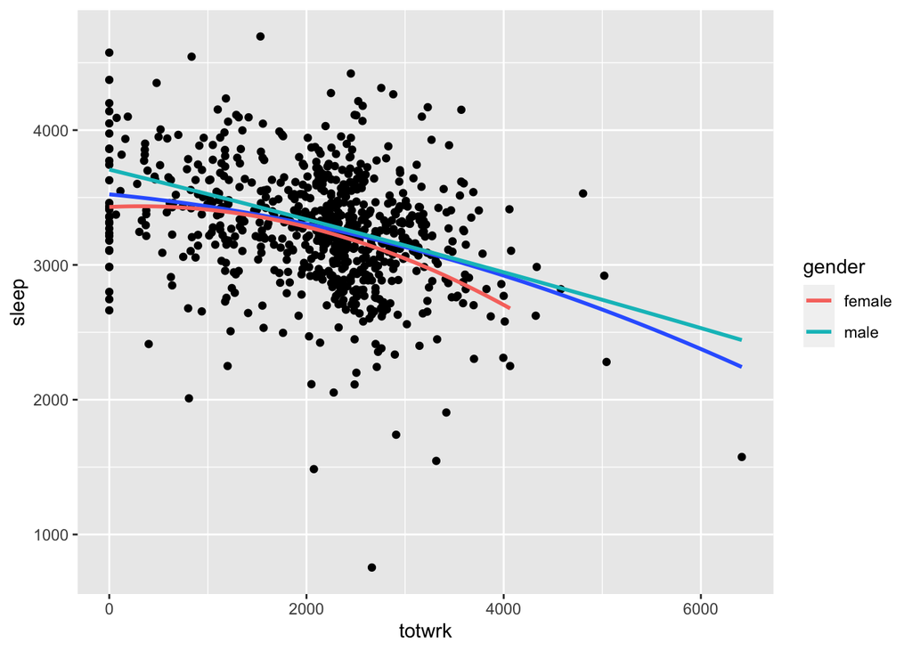

Рассмотрим ререссию **sleep на age, age^2** и подгоним отдельно для М, отдельно для Ж и по полному датасету

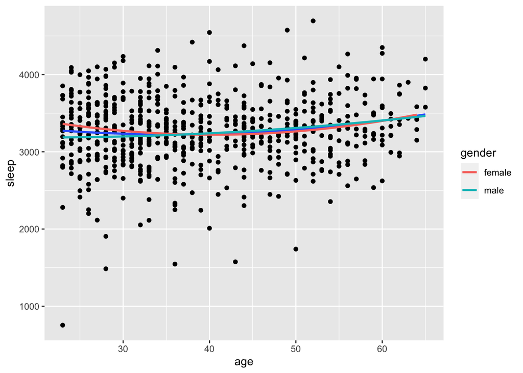

Рассмотрим регрессию **sleep/60 на totwrk, age, age^2, south, smsa, marr**:

- для M: $sleep/60=\beta_0+\beta_1totwrk+\beta_2age+\beta_3age^2+\beta_4south+\beta_5smsa+\beta_6marr+u$
- для Ж: $sleep/60=\gamma_0+\gamma_1totwrk+\gamma_2age+\gamma_3age^2+\gamma_4south+\gamma_5smsa+\gamma_6marr+v$

Результаты подгонки:

```
=================================================
                         Dependent variable:
                    -----------------------------
                              sleep/60
                        М         Ж       общая
                       (1)       (2)       (3)
-------------------------------------------------
totwrk              -0.003*** -0.002*** -0.002***
                    (0.0004)  (0.0005)  (0.0003)

age                   0.122    -0.444    -0.123
                     (0.237)   (0.306)   (0.188)

I(age2)              -0.001     0.006     0.002
                     (0.003)   (0.004)   (0.002)

south                 1.027    2.153**   1.574**
                     (0.933)   (1.065)   (0.699)

smsa                 -1.292*   -0.561    -0.867
                     (0.719)   (0.868)   (0.553)

marr                  0.136     1.055     0.874
                     (1.029)   (0.987)   (0.690)

Constant            58.634*** 65.558*** 60.421***
                     (4.811)   (5.833)   (3.672)

-------------------------------------------------
Observations           400       306       706
R2                    0.161     0.109     0.125
Adjusted R2           0.148     0.091     0.117
Residual Std. Error   6.696     7.250     6.960
F Statistic         12.538*** 6.082***  16.577***
=================================================
Note:                 *p<0.1; **p<0.05; ***p<0.01
```

Тест Чоу на однородность выборок $H_0:\beta_j=\gamma_j (j=0,\ldots,6)$. Объём выборки 706, уровень значимости 1%.

Остаточные суммы квадратов:

```
=============================
только М  только Ж    Общая
-----------------------------
17618.980 15717.920 33859.800
-----------------------------
```

Вычислите тестовую статистику. **Ответ округлите до 3-х десятичных знаков.**

Ответ

```
[1] 1.551
```

Вычислите критическое значение. **Ответ округлите до 3-х десятичных знаков.**

Ответ

```
[1] 2.665
```

Значимы ли структурные изменения? Ответ:

```
[1] "Незначимы"
```

## 4.2 sleep equation #2

Для набора данных `sleep75` рассмотрим регрессию **sleep/60 на totwrk, age, age^2, male, smsa**. Регрессия была оценена на полному набору данных, только по жителям юга и только по жителям севера. Результаты приведены в таблице

```
=================================================
                         Dependent variable:
                    -----------------------------
                              sleep/60
                      общая      юг       север
                       (1)       (2)       (3)
-------------------------------------------------
Constant            61.477*** 60.128*** 61.059***
                     (3.637)   (8.193)   (4.034)

totwrk              -0.003***  -0.001   -0.003***
                    (0.0003)   (0.001)  (0.0003)

age                  -0.127    -0.252    -0.079
                     (0.187)   (0.422)   (0.206)

I(age2)               0.002     0.005     0.001
                     (0.002)   (0.005)   (0.002)

male                 1.445**    0.005   1.951***
                     (0.571)   (1.256)   (0.640)

smsa                -1.247**   -0.155    -1.106*
                     (0.535)   (1.649)   (0.584)

-------------------------------------------------
RSS                 33860.554 5462.295  27640.206
Observations           706       130       576
R2                    0.125     0.119     0.143
Adjusted R2           0.118     0.083     0.135
Residual Std. Error   6.955     6.637     6.964
F Statistic         19.917*** 3.334***  18.980***
=================================================
Note:                 *p<0.1; **p<0.05; ***p<0.01
```

Уровень значимости 5%. Вычислите тестовую статистику теста Чоу на структурные сдвиги относительно географической переменной. **Ответ округлите до 3-х десятичных знаков.**

Ответ:

```
[1] 2.649
```

Вычислите критическое значение. **Ответ округлите до 3-х десятичных знаков.**

Ответ

```
[1] 2.112
```

Значимы ли структурные изменения? Ответ:

```
[1] "Значимы"
```

## 4.3 wage equation #1

Для набора данных `wage1` рассмотрим линейную регрессию **log(wage) на exper и exper^2** и подгоним отдельно для М, отдельно для Ж и по полному датасету

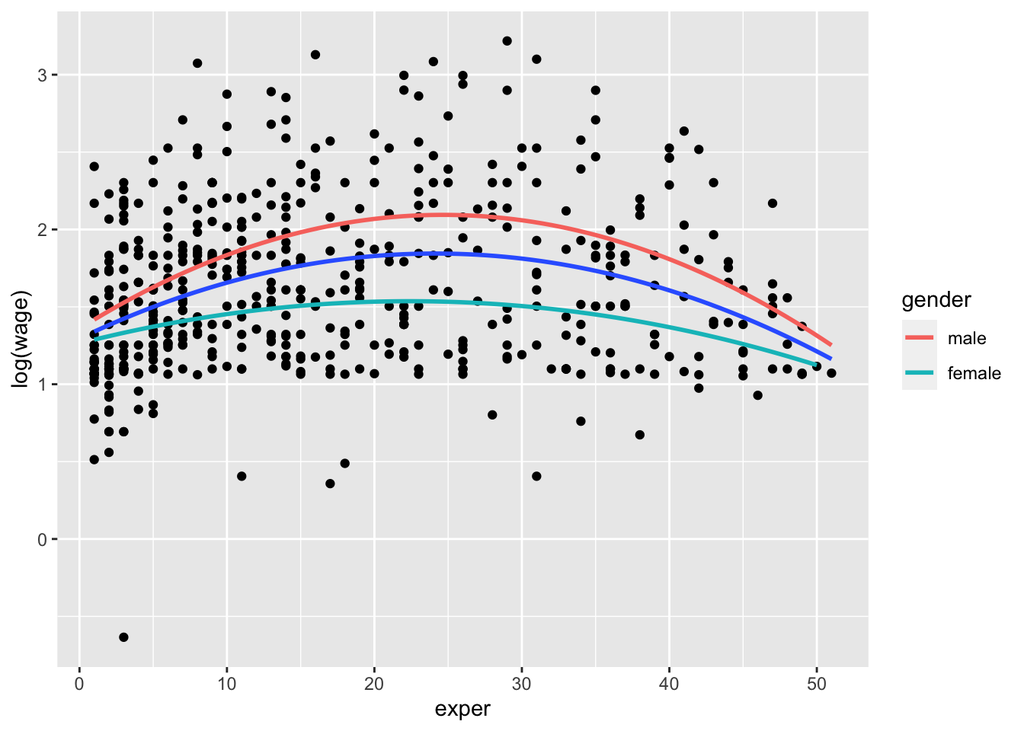

Рассмотрим регрессию **log(wage) на exper, exper^2, married, smsa**:

- для M: $\log(wage)=\beta_0+\beta_1exper+\beta_2exper^2+\beta_3married+\beta_4smsa+u$
- для Ж: $\log(wage)=\gamma_0+\gamma_1exper+\gamma_2exper^2+\gamma_3married+\gamma_4smsa+v$

Результаты подгонки:

```
=================================================
                         Dependent variable:
                    -----------------------------
                              log(wage)
                        М         Ж       общая
                       (1)       (2)       (3)
-------------------------------------------------
exper               0.044***  0.027***  0.036***
                     (0.008)   (0.008)   (0.006)

I(exper2)           -0.001*** -0.001*** -0.001***
                    (0.0002)  (0.0002)  (0.0001)

married             0.289***    0.009   0.208***
                     (0.067)   (0.060)   (0.048)

smsa                0.292***  0.222***  0.272***
                     (0.061)   (0.062)   (0.047)

Constant            1.079***  1.072***  1.044***
                     (0.079)   (0.080)   (0.061)

-------------------------------------------------
Observations           274       252       526
R2                    0.286     0.090     0.180
Adjusted R2           0.275     0.075     0.174
Residual Std. Error   0.455     0.427     0.483
F Statistic         26.894*** 6.121***  28.615***
=================================================
Note:                 *p<0.1; **p<0.05; ***p<0.01
```

Тест Чоу на однородность выборок $H_0:\beta_j=\gamma_j (j=0,1,2,3,4)$. Объём выборки 526, уровень значимости 5%.

Остаточные суммы квадратов:

```
=========================
только М только Ж  Общая
-------------------------
55.778    45.066  121.613
-------------------------
```

Вычислите тестовую статистику. **Ответ округлите до 3-х десятичных знаков.**

Ответ

```
[1] 21.254
```

Вычислите критическое значение. **Ответ округлите до 3-х десятичных знаков.**

Ответ

```
[1] 2.231
```

Значимы ли структурные изменения? Ответ:

```
[1] "Значимы"
```

## 4.4 wage equation #2

Для набора данных `wage1` рассмотрим линейную регрессию **log(wage) на exper, exper^2, female, smsa**. Регрессия была оценена на полному набору данных, только по женатым/замужним и только по неженатым/незамужним. Результаты приведены в таблице

```
=================================================
                         Dependent variable:
                    -----------------------------
                              log(wage)
                      общая      жен      нежет
                       (1)       (2)       (3)
-------------------------------------------------
Constant            1.293***  1.588***  1.076***
                     (0.060)   (0.088)   (0.089)

exper               0.044***  0.025***  0.045***
                     (0.005)   (0.008)   (0.008)

I(exper2)           -0.001*** -0.001*** -0.001***
                    (0.0001)  (0.0002)  (0.0002)

female              -0.382*** -0.496*** -0.168**
                     (0.040)   (0.049)   (0.065)

smsa                0.264***  0.259***  0.276***
                     (0.044)   (0.052)   (0.077)

-------------------------------------------------
RSS                  106.835   58.616    41.839
Observations           526       320       206
R2                    0.280     0.318     0.188
Adjusted R2           0.274     0.309     0.172
Residual Std. Error   0.453     0.431     0.456
F Statistic         50.589*** 36.702*** 11.637***
=================================================
Note:                 *p<0.1; **p<0.05; ***p<0.01
```

Уровень значимости 5%. Вычислите тестовую статистику теста Чоу на структурные сдвиги относительно семейного статуса. **Ответ округлите до 3-х десятичных знаков.**

Ответ:

```
[1] 6.554
```

Вычислите критическое значение. **Ответ округлите до 3-х десятичных знаков.**

Ответ

```
[1] 2.231
```

Значимы ли структурные изменения? Ответ:

```
[1] "Значимы"
```